# COVID-19 Air Quality: San Francisco

Cari Gostic

4/5/2020

## Introduction

San Francisco was the first city in the US to declare a shelter-in-place ordinance. How has this drastic change in human activity impacted the air quality in the city? To answer this question, I’ll examine how ambient Nitrogen Dioxide [NO2] levels have changed from January 1st through April 5th. My initial hypothesis based on my [monitoring app](https://sf-aq-covid19.herokuapp.com/) is that the concentration of NO2 has decreased on average, and that the weekly cycle has collapsed to a smaller range.

#### Why Nitrogen Dioxide?

Most NO2 concentration that is measured in cities is a result of human activity. Exhaust from automobiles accounts for up to 80% of urban NO2 pollution. Therefore, any significant change in NO2 concentration can be reasonably linked to human behavior. On the other hand, fluctuations in other common pollutants like Ozone and PM 2.5 might be caused by any combination of wind, pressure, temperature, and other meteorological factors in addition to human activity. I will therefore use NO2 as a proxy for the effect of altered human behavor on air quality in general.

Source: [AU Government Air Quality Fact Sheet](https://www.environment.gov.au/protection/publications/factsheet-nitrogen-dioxide-no2)

#### San Francisco COVID-19 Timeline

- Jan 26: The first case of COVID-19 is confirmed in California (Orange County)
- Feb 25: San Francisco declares a local emergency
- Mar 02: California declares a state of emergency
- Mar 11: San Francisco bans gatherings greater than 1,000 people, the WHO declares COVID-19 a global pandemic
- Mar 12: San Francisco schools close
- Mar 13: San Francisco bans gatherings greater than 100 people
- Mar 15: California closes bars, clubs, and wineries. Allowed capacity at restaurants is reduced.
- Mar 17: Shelter in Place enforced in San Francisco and neighboring counties

Source: [ABC 7 News](https://abc7news.com/timeline-of-coronavirus-us-coronvirus-bay-area-sf/6047519/)

## Analysis

### Data

All data comes from the [California Air Resources Board Open Data Portal](https://www.arb.ca.gov/aqmis2/aqdselect.php)

The data set consists of hourly NO2 measurements from various sites in the Bay Area. All measurements are in ppm. Visit the accompanying [air quality monitoring app] to view a map of these sensors.

First, I’ll read in the data and remove NA values. There are 8 NA values out of 2166 in this time series of NO2 measurements from January 1st April 5th, 2020.

```r
aq_2020 <- read_csv('data/NO2_PICKDATA_2020-4-5.csv')
```

```r
# Drop NA values
aq <- aq_2020 %>% select(site, date, start_hour, value, variable, units, name) %>% drop_na()
aq %>% head()
```

| site | date | start_hour | value | variable | units | name |
| --- | --- | --- | --- | --- | --- | --- |
| 2373 | 2020-01-01 | 0 | 0.0071 | NO2 | Parts Per Million ( ppm ) | San Francisco-Arkansas Street |
| 2373 | 2020-01-01 | 1 | 0.0175 | NO2 | Parts Per Million ( ppm ) | San Francisco-Arkansas Street |
| 2373 | 2020-01-01 | 2 | 0.0236 | NO2 | Parts Per Million ( ppm ) | San Francisco-Arkansas Street |
| 2373 | 2020-01-01 | 4 | 0.0207 | NO2 | Parts Per Million ( ppm ) | San Francisco-Arkansas Street |
| 2373 | 2020-01-01 | 5 | 0.0193 | NO2 | Parts Per Million ( ppm ) | San Francisco-Arkansas Street |
| 2373 | 2020-01-01 | 6 | 0.0216 | NO2 | Parts Per Million ( ppm ) | San Francisco-Arkansas Street |

I’ll focus on a single site in the heart of downtown, *San Francisco-Arkansas Street*. Just the first few rows of data above reveal that the hourly measurements are sporadic, so I’ll aggregate these measurements to a daily average before creating a time series.

The code below converts the data to a weekly time series object.

```r
# Select San Francisco-Arkansas Street
aq_sfas <- aq %>% filter(name == 'San Francisco-Arkansas Street')
# Group by date
aq_daily <- aq %>% group_by(date) %>% summarize(daily_avg = mean(value))
aq_daily_zoo <- zoo(aq_daily$daily_avg, strptime(aq_daily$date, format = '%Y-%m-%d'))
# Convert to time series (weekly frequency [7], starting on a Wednesday [4])
aq_ts <- ts(aq_daily_zoo, start = c(1,4), freq = 7)
print(aq_ts, calendar = TRUE)
```

```
##             p1          p2          p3          p4          p5          p6
## 1                                      0.010273913 0.023531818 0.023331818
## 2  0.010656522 0.023191304 0.013834783 0.012100000 0.012482609 0.013709091
## 3  0.009443478 0.010304348 0.009069565 0.015065217 0.011178261 0.019500000
## 4  0.013352174 0.015830435 0.010047826 0.019704348 0.020833333 0.013395455
## 5  0.004243478 0.010540909 0.010330435 0.015713043 0.014613043 0.021777273
## 6  0.004482609 0.006256522 0.012865217 0.020517391 0.020139130 0.016527273
## 7  0.004365217 0.017056522 0.021365217 0.020521739 0.004591304 0.010845455
## 8  0.006491304 0.015278261 0.017708696 0.014773913 0.024286957 0.019800000
## 9  0.004969565 0.016343478 0.023678261 0.022178261 0.027473913 0.019677273
## 10 0.006026087 0.009252174 0.017880952 0.015013043 0.006940909 0.004363636
## 11 0.008052174 0.016860870 0.011923810 0.010708696 0.011273913 0.005609524
## 12 0.003091304 0.009460870 0.008152174 0.006430435 0.009265217 0.009963636
## 13 0.010073913 0.004213043 0.004369565 0.007417391 0.007643478 0.004045455
## 14 0.004269565 0.005473913 0.003926087 0.005052174 0.008904348 0.005822727
```

[output cut: 17 more lines]

### Exploratory Data Analysis

I’ll first do an exploratory analysis using a seasonal decomposition of the time series.

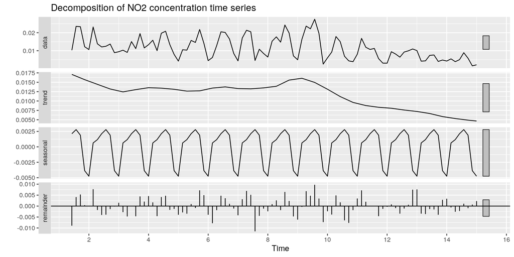

```r
stl_aq <- stl(aq_ts, 'periodic', t.window = 21)
autoplot(stl_aq, main = "Decomposition of NO2 concentration time series")
```

The trend component is calculated using the loess method over a 3-week window. There is a clear downward trend in nitrogen dioxide concentration starting in week 9 (the last week of February). This coincides with San Francisco’s declaration of a local emergency. The WHO declared COVID-19 a global pandemic in week 11, and San Francisco enacted the shelter-in-place ordinance in week 12. The cyclical component shows higher values of NO2 concentration during the work week, likely due to increased commuter traffic, and low points on weekends (particularly Sunday).

### Model

To examine how drastic the hypothesized decrease in air quality is, I’ll separate the time series into pre-pandemic (training) and post-pandemic (testing) series with a cutoff on March 11th. I am choosing March 11th because this was the first day that the city of San Francisco placed an ordinance that drastically altered human behavior (the ban of large gatherings).

```r
ts_pre <- ts(window(aq_daily_zoo,
                    start = as.Date('2020-01-01'),
                    end = as.Date('2020-03-11')),
             start = c(1, 4),
             freq = 7)
ts_post <- ts(window(aq_daily_zoo, start = as.Date('2020-03-11')),
              start = c(1, 4),
              freq = 7)
```

The code below finds the best-fit ARIMA model for the pre-pandemic time series.

```r
pre_model <- auto.arima(ts_pre)
pre_model
```

```
## Series: ts_pre
## ARIMA(0,0,1)(1,0,1)[7] with non-zero mean
##
## Coefficients:
##          ma1    sar1     sma1    mean
##       0.4999  0.9172  -0.7375  0.0132
## s.e.  0.0992  0.1183   0.2139  0.0017
##
## sigma^2 estimated as 2.478e-05:  log likelihood=276.38
## AIC=-542.76   AICc=-541.84   BIC=-531.45
```

The results indicate an MA(1) process with an MA(1) and AR(1) seasonal component of period 7 (weekly). Below, a Ljung-Box test indicates that the model is well-fit to the time series as there are no significant p-values at the alpha=0.05 level (blue dotted line).

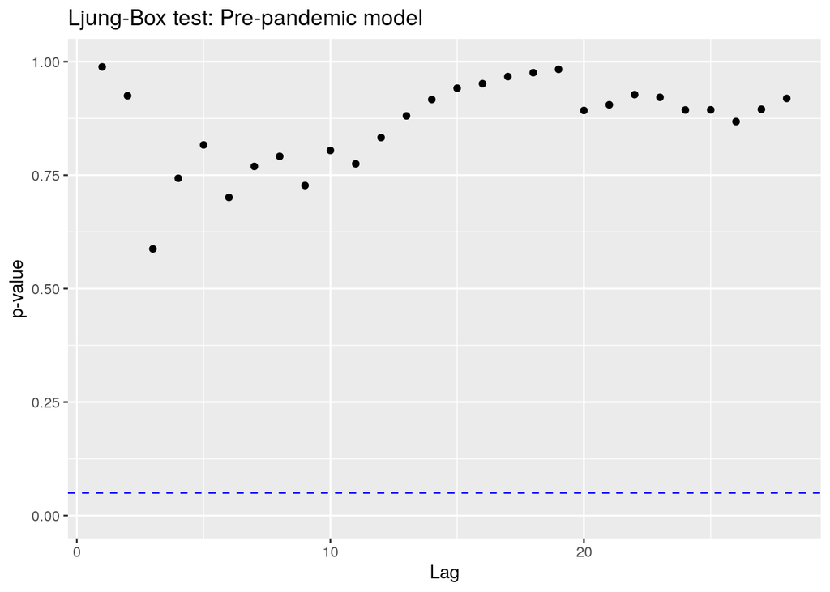

```r
#' Creates a scatter plot of Ljung-Box p-values
#' calcualted from the residuals of a fit
#' time series model
#'
#' @param model a fit time series model
#'
#' @return a scatter plot of Ljung-Box p-values for lags 1-28
#'
#' @examples
#' auto_arima(aq_ts)
lj_plot <- function(model) {
  lags <- 1:28
  lj_values <- map_dbl(lags, function(i) Box.test(resid(model), lag = i)$p.value)

  ggplot() +
      geom_point(aes(x=lags, y=lj_values)) +
      ylim(0,1) +
      geom_hline(aes(yintercept=0.05), color = 'blue', linetype = 'dashed') +
      labs(title = 'Ljung-Box test: Pre-pandemic model', x = 'Lag', y = 'p-value')
}

lj_plot(pre_model)
```

### Are the post-pandemic values extreme?

Below, I forecast the 3 week post-pandemic period using the model trained on the 10-week pre-pandemic period.

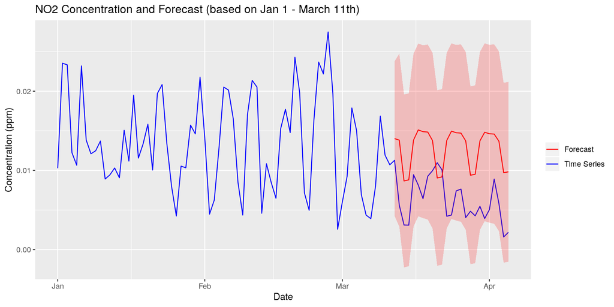

```r
forecast_df<- data.frame(date = aq_daily %>% filter(date > '2020-03-11') %>% select(date),
                         forecast(pre_model, level = .95, h = 25))
df_plot <- merge(aq_daily, forecast_df, by = 'date', all = TRUE)
ggplot(df_plot) +
  geom_line(aes(date, daily_avg, color='Time Series')) +
  geom_line(aes(date, Point.Forecast, color = 'Forecast')) +
  geom_ribbon(aes(date, ymin=Lo.95, ymax=Hi.95),
              fill = 'red',
              alpha = 0.2) +
  scale_color_manual("", values = c('red', 'blue')) +
  labs(title = 'NO2 Concentration and Forecast (based on Jan 1 - March 11th)',
       y = 'Concentration (ppm)',
       x = 'Date')
```

### Change in average NO2 concentration

Using a Welch Student’s T-test to allow for different variances, I’ll test the null hypothesis that the mean NO2 values are the same pre-pandemic and post-pandemic.

```r
tidy(t.test(ts_pre, ts_post))
```

| estimate | estimate1 | estimate2 | statistic | p.value | parameter | conf.low | conf.high | method | alternative |
| --- | --- | --- | --- | --- | --- | --- | --- | --- | --- |
| 0.00696018 | 0.01341729 | 0.006457108 | 7.571178 | 3.44317e-11 | 88.03917 | 0.005133277 | 0.008787084 | Welch Two Sample t-test | two.sided |

### Change in NO2 cycle

Earlier, I speculated that the cyclical nature of the NO2 time series seemed to be collapsing. Below I’ll compare the mid-week values in pre- and post-pandemic data sets.

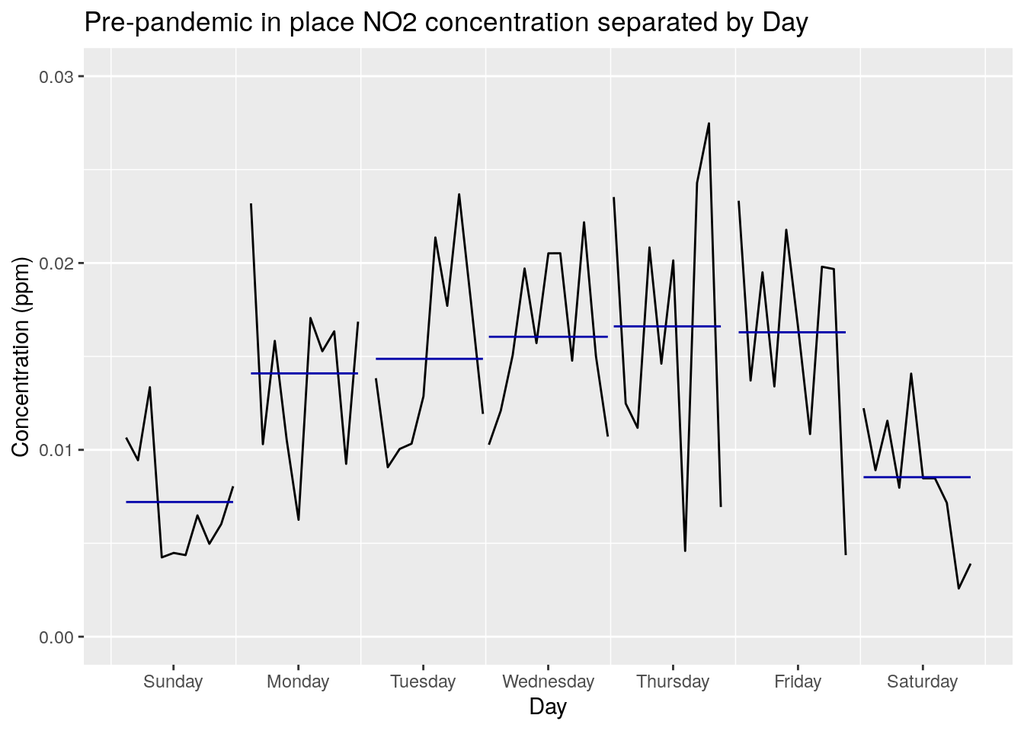

```r
ggsubseriesplot(ts_pre,
                ylab = 'Concentration (ppm)',
                main = 'Pre-pandemic in place NO2 concentration separated by Day') +
  ylim(0,0.03)
```

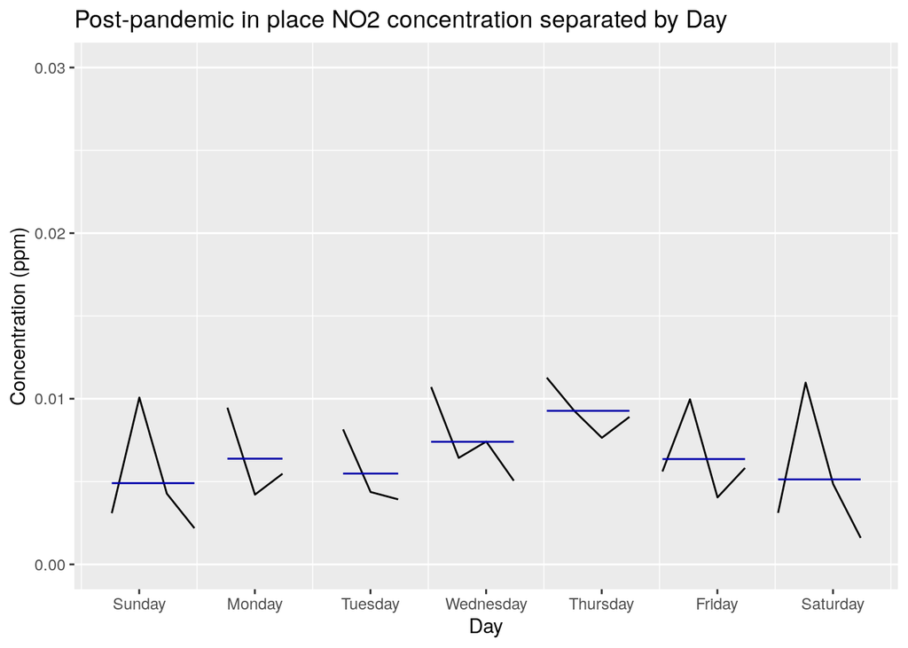

```r
ggsubseriesplot(ts_post,
                ylab = 'Concentration (ppm)',
                main = 'Post-pandemic in place NO2 concentration separated by Day') +
  ylim(0,0.03)
```

**Experiments:**

```r
cyc <- cycle(ts_pre)
# separate time series into weekend (saturday and sunday) and weekday (monday-Friday)
weekend_pre <- ts_pre[cyc == 1 | cyc == 7]
weekday_pre <- ts_pre[cyc > 1 & cyc < 7]
cyc_post = cycle(ts_post)
weekend_post <- ts_post[cyc_post == 1 | cyc_post == 7]
weekday_post <- ts_post[cyc_post > 1 & cyc_post < 7]

# Welch's student t-test experiments (summarized in table)
weekday_comp <- tidy(t.test(weekday_pre, weekday_post))
weekend_comp <- tidy(t.test(weekend_pre, weekend_post))
pre <- tidy(t.test(weekday_pre, weekend_pre))
post <- tidy(t.test(weekday_post, weekend_post))

p_value <- map_dbl(c(pre$p.value,
       post$p.value,
       weekday_comp$p.value,
       weekend_comp$p.value), ~ format(.x, scientific = FALSE) %>% as.numeric() %>% round(4))
diff_est <- map_dbl(c(pre$estimate,
                      post$estimate,
                      weekday_comp$estimate,
                      weekend_comp$estimate), ~ round(.x, 4))

data.frame(experiment = c("Pre weekday vs. Pre Weekend",
                          "Post weekday vs. Post Weekend",
                          "Pre Weekday vs. Post Weekday",
                          "Pre Weekend vs. Post Weekend"),
           p_value = p_value,
           difference_estimate = diff_est)
```

| experiment | p_value | difference_estimate |
| --- | --- | --- |
| Pre weekday vs. Pre Weekend | 0.0000 | 0.0077 |
| Post weekday vs. Post Weekend | 0.1637 | 0.0021 |
| Pre Weekday vs. Post Weekday | 0.0000 | 0.0085 |
| Pre Weekend vs. Post Weekend | 0.0741 | 0.0029 |

## Summary and conclusions

Overall, the mean concentration of Nitrogen Dioxide in San Francisco has significantly decreased since March 11th, the day when San Francisco enacted it’s first mandatory policy related to social distancing. Though the magnitude of NO2 concentration is not wildly outside the range seen in the pre-pandemic period, the weekly cycle of NO2 concentration has perceptibly changed. In the pre-pandemic period, NO2 concentration followed a weekly cycle that was likely related to commuter traffic. Concentrations during the work-week were noticeably higher than on the weekends. This new post-pandemic time series of NO2 concentration is centered at a lower mean value, and work-week-level NO2 concentration is no longer significantly different than weekend level. Though the magnitude of the weekly minimum of NO2 concentration has not measurably changed, the weekly maximum no longer predictably spikes as it did in the pre-pandemic period. Self-quarantine and social distancing has shifted NO2 concentrations in San Francisco into a state of perpetual weekend.